# ECOM30004/90004 Time Series Analysis and Forecasting Tutorial 11 Tutor: Pengyun (Kevin) Chen University of Melbourne Semester 2, 2026

## Notice

**Conditions of Use**

- This document is intended for personal use and is NOT meant to be shared on the internet (e.g. Studocu, ThinkSwap, StudentVIP, Coursehero, etc.)
- Do not share this document with anyone, even if they are enrolled in ECOM30004/90004.
- Official course materials, such as lecture slides, tutorial sheets and prescribed readings should always be your primary point of reference.
- Slides accessible here: `pengyunc.github.io/TSAF_Week11`
- Download HTML versions here: [Dropbox Link](https://www.dropbox.com/scl/fo/aoxoud5ex0j42hsrod3dg/ADblAt_jJ9hpESZME9FDcWc?rlkey=0s0oyf1y3uokzvlhbzxe2yy3g&st=kx2yupzr&dl=0)
- My consultations for Weeks 11 and 12:
  $$\boxed{\;\textsf{Wednesday 3pm-4pm, FBE 455}\;}$$

## This tutorial: Forecasting with AR-GARCH

In this tutorial, we use an AR-GARCH model to generate ex-ante forecasts of S&P 500 returns and volatilities, and investigate whether non-normality materially affects forecasting performance.

**Activities**

- Exercise 1: Understanding R output
- Exercise 2: Event Matching with estimated volatility series
- Exercise 3: Investigating the distributional properties of return series and standardised residuals
- Exercise 4: Constructing point forecasts and normal prediction intervals
- Exercise 5: Using bootstrapping to build empirical prediction intervals and comparing them with the normal case

## Initialisation

In Self-Directed Activities 10, you have carried out a model specification exercise for the S&P 500 returns time series that comes with the `rugarch` package.

You arrived at an AR(4)-GARCH(1,1) specification.

Please install the R packages `rugarch` and `moments` before proceeding:

```r
install.packages("rugarch")
install.packages("moments")
```

Set up as follows:

```r
library(rugarch)
library(moments)
data("sp500ret")
Y <- sp500ret$SP500RET*100

h <- 5
n <- length(Y)-h
Yf <- ts(Y[(n+1):length(Y)], start=n+1)
Y <- ts(Y[1:n], start=1, end=n)

AR4GARCH11 <- ugarchfit(data=Y,
    ugarchspec(variance.model=list(garchOrder=c(1,1)),
               mean.model=list(armaOrder=c(4,0))))
```

## Exercise 1

Write out the full set of estimated mean and variance equations that constitute this model.

The estimated coefficients can be obtained as follows:

```r
print(round(coef(AR4GARCH11), 3))
```

```
    mu    ar1    ar2    ar3    ar4  omega alpha1  beta1
 0.052 -0.010 -0.015 -0.019 -0.043  0.014  0.089  0.904
```

The estimated AR(4)-GARCH(1,1) model is therefore:
$$\begin{align}
Y_{t}&=0.052+\widehat{Z}_{t}\\
\widehat{Z}_{t}&=-0.01\widehat{Z}_{t-1}-0.015\widehat{Z}_{t-2}-0.019\widehat{Z}_{t-3}-0.043\widehat{Z}_{t-4}+\widehat{U}_{t}\\
\widehat{\sigma}_{t}^{2}&=0.014+0.089\widehat{U}^{2}_{t-1}+0.904\widehat{\sigma}^{2}_{t-1}
\end{align}$$

## Exercise 2

Obtain the time series of estimated standard deviations, denoted $\widehat{\sigma}_{t}=\sqrt{\widehat{\mathbb{E}}(U_{t}^{2}\mid\mathscr{Y}_{t-1})}$, implied by the model. Plot this series.

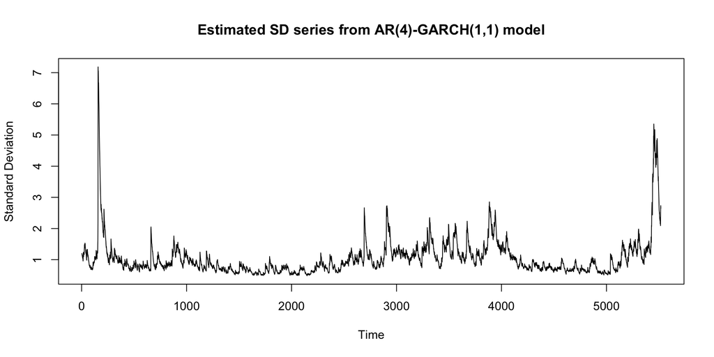

```r
AR4GARCH11_sigma <- ts(sigma(AR4GARCH11), start=1, end=n)

plot(AR4GARCH11_sigma,
     main = "Estimated SD series from AR(4)-GARCH(1,1) model",
     ylab = "Standard Deviation")
```

## Exercise 2

Recalling the time series covers the period 10 March 1987 to 30 January 2009, discuss which “real world” events might correspond to the most volatile periods.

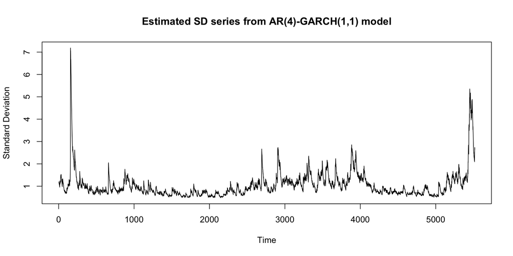

```r
AR4GARCH11_sigma <- ts(sigma(AR4GARCH11), start=1, end=n)

plot(AR4GARCH11_sigma,
     main = "Estimated SD series from AR(4)-GARCH(1,1) model",
     ylab = "Standard Deviation")
```

$\longleftarrow\;\text{1987 Stock Market Crash}$

$\text{Global Financial Crisis}\;\longrightarrow$

## Exercise 3(a)

1. Compute the mean, standard deviation, skewness and kurtosis of the return series `Y`. The R commands `mean` and `sd` are standard, while `skewness` and `kurtosis` are obtained from the `moments` package.
- The skewness and kurtosis are standard descriptive statistics given by:
  $$\text{Skewness}=\frac{\frac{1}{n}\sum^{n}_{t=1}(Y_{t}-\bar{Y})^{3}}{s^{3}};\quad\text{Kurtosis}=\frac{\frac{1}{n}\sum^{n}_{t=1}(Y_{t}-\bar{Y})^{4}}{s^{4}}$$
  where $s$ is the sample standard deviation.
- Skewness:
  - $\text{Skewness}=0$ if the distribution is symmetric;
  - $\text{Skewness}>0$ if right-skewed;
  - $\text{Skewness}<0$ if left-skewed.
- Kurtosis: Measure of “tail thickness”
  - When $\text{Kurtosis}>3$, the tails are “fatter” than a normal distribution (more outliers).

## Exercise 3(a)

1. Compute the mean, standard deviation, skewness and kurtosis of the return series `Y`. The R commands `mean` and `sd` are standard, while `skewness` and `kurtosis` are obtained from the `moments` package.
- Moments
- Histogram

```r
stats_Y = c(mean(Y), sd(Y), skewness(Y), kurtosis(Y))
names(stats_Y) <- c("mean", "sd", "skewness", "kurtosis")
print(round(stats_Y, 3))
```

```
    mean       sd skewness kurtosis
   0.019    1.193   -1.541   36.185
```

- The mean return is slightly positive (share prices having a long term overall tendency to increase over this period).
- The skewness is negative ($-1.541$) and kurtosis of $\approx 36$ very much greater than 3, implying non-normality.
- Both skewness and kurtosis will be inflated in magnitude by the large negative outlier for the 1987 crash, as well as some of the other outliers.

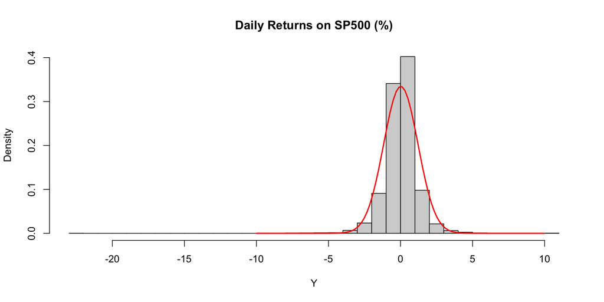

```r
hist(Y, breaks = 40, freq = FALSE, main = "Daily Returns on SP500 (%)")
x <- seq(from=-10, to=10, length.out=100)
lines(x, dnorm(x, mean=mean(Y), sd = sd(Y)), col="red", lwd=2)
```

$\mathrm{N}(0.019, 1.193^2)$

The large kurtosis is evident in the long tails of the histogram, counterbalanced by the taller than normal peak around the mean.

## Exercise 3(b)

2. Obtain the standard residuals $\widehat{U}_{t}^*$ from the AR(4)-GARCH(1,1) model, and investigate their distribution in the same way as part (a).

In a general AR($p$)-GARCH(1,1) model of the form
$$\begin{align}
Y_{t}&=\mu +Z_{t}\\
Z_{t}&=\phi_{1}Z_{t-1}+\cdots+\phi_{p}Z_{t-p}+U_{t}\\
\sigma_{t}^{2}&=\omega+\alpha_{1}U_{t-1}^{2}+\gamma_{1}\sigma^{2}_{t-1}
\end{align}$$

where $\sigma^{2}=\operatorname{var}(U_{t}\mid \mathscr{Y}_{t-1})$, the *standardised prediction errors $U_{t}^*$*
$$U_{t}^{*}=\frac{U_{t}}{\sigma_{t}}$$
will be conditionally homoskedastic, assuming the model is well specified:
$$\operatorname{var}(U_{t}^*\mid\mathscr{Y}_{t-1})=1$$

The distribution of these standardised prediction errors determines the distribution that is appropriate for the prediction intervals.

- If $U_{t}^*$ is normally distributed then the normal prediction intervals will be correct.
- Otherwise, the normal prediction intervals may be only approximate and not have the required 95% coverage property.

## Exercise 3(b)

2. Obtain the standard residuals $\widehat{U}_{t}^*$ from the AR(4)-GARCH(1,1) model, and investigate their distribution in the same way as part (a).

```r
Us <- residuals(AR4GARCH11, standardize = TRUE)
```

- Moments
- Histogram

```r
stats_Us = c(mean(Us), sd(Us), skewness(Us), kurtosis(Us))
names(stats_Us) <- c("mean", "sd", "skewness", "kurtosis")
print(round(stats_Us, 3))
```

```
    mean       sd skewness kurtosis
  -0.035    0.999   -0.750    8.332
```

The descriptive statistics and histogram reveal that the residuals retain clear signs of non-normality (some negative skewness and substantial excess kurtosis) although these are reduced relative to the same measures for the original data series.

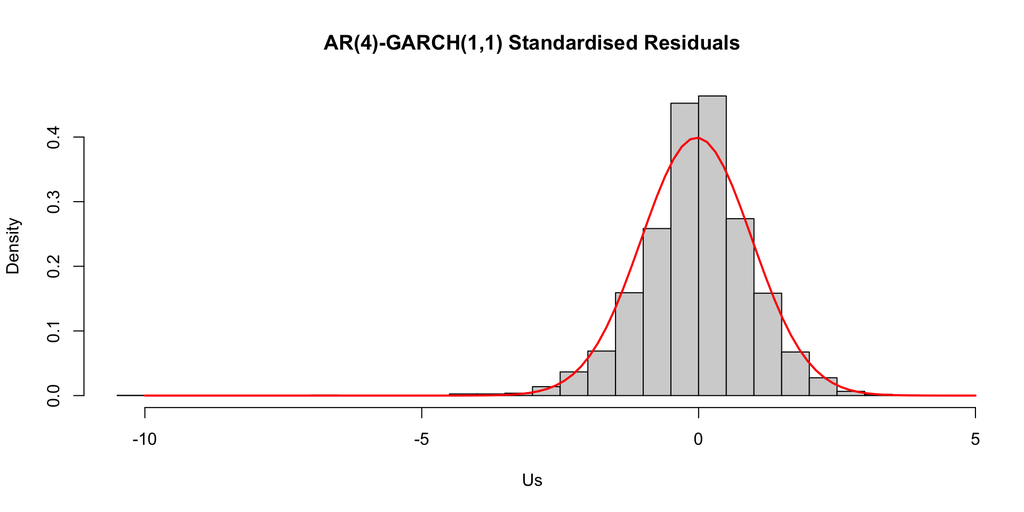

```r
hist(Us, breaks = 40, freq = FALSE,
     main = "AR(4)-GARCH(1,1) Standardised Residuals")
x <- seq(from=-10, to=5, length.out=100)
lines(x, dnorm(x, mean=mean(Us), sd = sd(Us)), col="red", lwd=2)
```

It is commonly the case with GARCH models that the standardised residuals are closely to normality than the original data, but still not close to approximately normal.

## Exercise 4

From the AR(4)-GARCH(1,1) model, obtain the point/mean forecasts for `Y` for 5 days into the future (one business week), the standard deviation for the forecasts, and the 95% normal prediction intervals.

- Code
- Results and Discussions
- Forecast Errors and RMSE

```r
AR4GARCH11f <- ugarchforecast(AR4GARCH11, n.ahead=h)

Point <- ts(c(fitted(AR4GARCH11f)), start=n+1, end=n+h)
Sigma <- ts(c(sigma(AR4GARCH11f)), start=n+1, end=n+h)
Lower <- ts(Point-1.96*Sigma, start=n+1, end=n+h)
Upper <- ts(Point+1.96*Sigma, start=n+1, end=n+h)

AR4GARCH11Forecasts <- data.frame(
                          Lower=round(Lower,3),
                          Point=round(Point,3),
                          Upper=round(Upper,3),
                          Actual=round(Yf,3),
                          Error=round(Yf-Point,3),
                          Sigma=round(Sigma,3))

print(AR4GARCH11Forecasts, row.names=FALSE)
```

```
  Lower  Point Upper Actual  Error Sigma
 -4.716  0.227 5.170  0.554  0.327 2.522
 -5.037 -0.108 4.822  1.087  1.194 2.515
 -4.807  0.110 5.026  3.301  3.191 2.508
 -4.874  0.030 4.933 -3.368 -3.398 2.502
 -4.844  0.047 4.937 -2.305 -2.352 2.495
```

Do the prediction intervals “cover” the actual values?

Yes - In this case the actual value turns out to lie within the prediction interval at all of the 5 forecast days.

Also, compute the forecast errors and the RMSE.

```r
ForecastError <- Yf - Point
print(ForecastError)
```

```
Time Series:
Start = 5519
End = 5523
Frequency = 1
[1]  0.3267866  1.1944080  3.1911270 -3.3979096 -2.3520959
```

```r
RMSE <- sqrt(mean(ForecastError^2))
cat("The RMSE for the forecasts is", round(RMSE, 3), "\n")
```

```
The RMSE for the forecasts is 2.4
```

## Exercise 5

Given the apparent non-normality of the model residuals, we may be motivated to compute the PIs using the bootstrap, rather than using the normal distribution critical values.

Bootstrapping: Constructing an empirical distribution by resampling from the data itself $\to$ treat the observed sample as if it were the population distribution

```r
AR4GARCH11fBS <- ugarchboot(AR4GARCH11, method="Partial",
                        n.ahead=h, n.bootpred=5000)
```

**What is happening behind the scenes?**

In each bootstrapping experiment, when `method="Partial"`:

- Construct the residuals using the estimated parameters
- Draw a bootstrapped sample (in our case, of length `n.ahead=h`), with replacement, from the observed set of residuals.
- Recalculate the forecasts given this sample and construct PIs.

The number of experiments is set under `n.bootpred=5000`.

This allows us to focus on the difference between the normal and non-normal bootstrap intervals. It is also computationally quicker!

## Exercise 5

Given the apparent non-normality of the model residuals, we may be motivated to compute the PIs using the bootstrap, rather than using the normal distribution critical values.

Bootstrapping: Constructing an empirical distribution by resampling from the data itself $\to$ treat the observed sample as if it were the population distribution

```r
AR4GARCH11fBS <- ugarchboot(AR4GARCH11, method="Partial",
                        n.ahead=h, n.bootpred=5000)
```

**What is happening behind the scenes?**

In each bootstrapping experiment, when `method="Full"`:

- Draw a bootstrapped sample, with replacement, from the original data, and re-estimate the model parameters.
- Construct the residuals using the estimated parameters
- Draw a bootstrapped sample (in our case, of length `n.ahead=h`), with replacement, from the observed set of residuals.
- Recalculate the forecasts given this sample and construct PIs.

The number of experiments is set under `n.bootpred=5000`.

## Exercise 5

Given the apparent non-normality of the model residuals, we may be motivated to compute the PIs using the bootstrap, rather than using the normal distribution critical values.

```r
AR4GARCH11fBS <- ugarchboot(AR4GARCH11, method="Partial",
                        n.ahead=h, n.bootpred=5000)
```

The object produced by `ugarchboot` contains a matrix `fseries` of forecast series. Here, each row corresponds to a simulated forecast path, and there are 5000 of them.

```r
print(AR4GARCH11fBS@fseries)
```

[output not shown]

[output cut: 4986 more lines]

Since bootstrapping involves randomness through data resampling, my prediction intervals should be similar to yours, though not exactly identical.

```r
LowerBS <- apply(AR4GARCH11fBS@fseries, 2, quantile, probs=0.025)
UpperBS <- apply(AR4GARCH11fBS@fseries, 2, quantile, probs=0.975)
MedianBS <- apply(AR4GARCH11fBS@fseries, 2, quantile, probs=0.5)

print(round(cbind(LowerBS, UpperBS, MedianBS),3))
```

```
     LowerBS UpperBS MedianBS
[1,]  -5.233   4.924    0.190
[2,]  -5.517   4.442   -0.077
[3,]  -5.052   4.764    0.044
[4,]  -5.138   4.630    0.059
[5,]  -5.054   4.883    0.089
```

The median (50% quantile) is taken here as the “Point Forecast”.

```r
NormalPI <- cbind(Lower, Upper, Point)
print(round(NormalPI,3))
```

```
Time Series:
Start = 5519
End = 5523
Frequency = 1
      Lower Upper  Point
5519 -4.716 5.170  0.227
5520 -5.037 4.822 -0.108
5521 -4.807 5.026  0.110
5522 -4.874 4.933  0.030
5523 -4.844 4.937  0.047
```

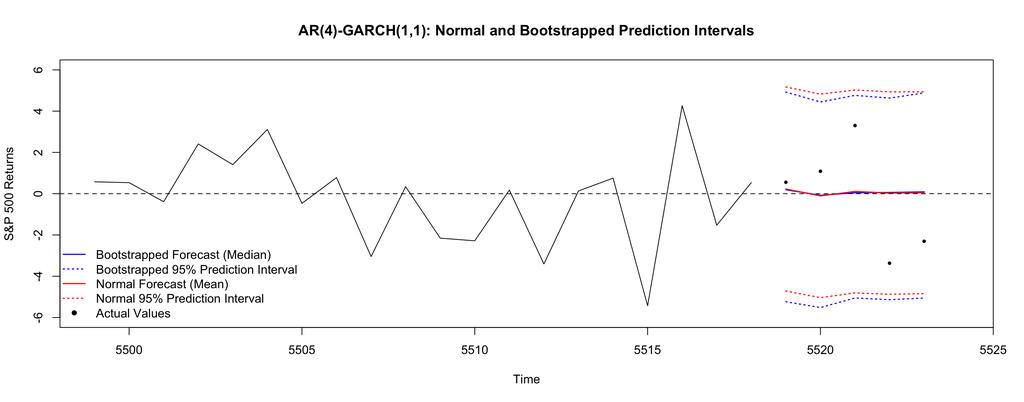

```r
Y_trimmed <- ts(Y[(length(Y)-19):length(Y)], start = (length(Y)-19))
LowerBS <- ts(LowerBS, start = 5519)
UpperBS <- ts(UpperBS, start = 5519)
MedianBS <- ts(MedianBS, start = 5519)

LowerNorm <- ts(Lower, start = 5519)
UpperNorm <- ts(Upper, start = 5519)
PointNorm <- ts(Point, start = 5519)

plot(
  Y_trimmed, type = "l",
  main = "AR(4)-GARCH(1,1): Normal and Bootstrapped Prediction Intervals",
  ylab = "S&P 500 Returns",
  xlim = c(5499, 5524),
  ylim = c(-6,6)
)
abline(h = 0, lty = 2)
lines(LowerBS, col = "blue", lty = 3, lwd = 1.5)
lines(UpperBS, col = "blue", lty = 3, lwd = 1.5)
lines(MedianBS, col = "blue", lty = 1, lwd = 1.5)
lines(LowerNorm, col = "red", lty = 3, lwd = 1.5)
lines(UpperNorm, col = "red", lty = 3, lwd = 1.5)
lines(PointNorm, col = "red", lty = 1, lwd = 1.5)
points(Yf, col = "black", pch = 19, cex = 0.5)

legend(
  "bottomleft",
  legend = c("Bootstrapped Forecast (Median)", "Bootstrapped 95% Prediction Interval",
    "Normal Forecast (Mean)", "Normal 95% Prediction Interval", "Actual Values"),
  col = c("blue", "blue", "red", "red", "black"),
  lty = c(1, 3, 1, 3, NA),
  lwd = c(1.5, 1.5, 1.5, 1.5, NA),
  pch = c(NA, NA, NA, NA, 19),
  pt.cex = c(NA, NA, NA, NA, 0.8),
  bty = "n"
)
```

## Exercise 5

Compare the bootstrap results to the mean point forecasts and normal prediction intervals in question 4.

- Plot
- RMSE
- Why Median?
- MAE
- What matters for PIs?
- Remarks

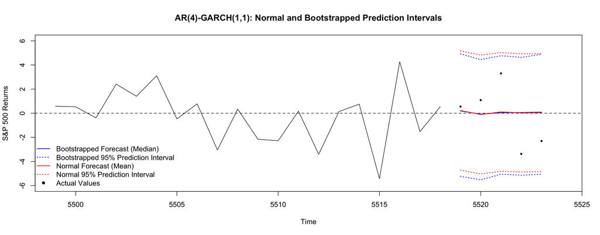

- Visually there are not huge differences between the bootstrap and normal results.
- Both upper and lower bounds of bootstrap PIs lie below the corresponding normal PIs $\to$ consistent with the negative skewness seen in the standardised residuals.

Normal (Mean as point forecast)

```r
RMSE <- sqrt(mean(ForecastError^2))
print(RMSE)
```

```
[1] 2.399785
```

Bootstrapping (Median as point forecast)

```r
MedianErrors <- Yf-MedianBS
RMSE_Median <- sqrt(mean(MedianErrors^2))
print(RMSE_Median)
```

```
[1] 2.431887
```

The RMSE for the median is slightly different than that for the mean, although this should not be over-stated since the practical differences between the two sets of forecasts are clearly very small.

Why we would consider the median instead of mean for forecasting, when we know the conditional mean is the optimal forecasting function?

- The conditional mean minimises the mean squared errors (MSE):
  $$\textsf{Mean Squared Error}=\frac{1}{h}\sum^{n+h}_{t=n+1}\widehat{U}_{t}^{2}$$
- The conditional median minimises the mean absolute errors (MAE):
  $$\textsf{Mean Absolute Error}=\frac{1}{h}\sum^{n+h}_{t=n+1}\left|\widehat{U}_{t}\right|$$

**Note:** The full model for the median would involve the estimation of *conditional quantiles*. Nevertheless, bootstrapping is an interesting sensitivity analysis for the importance of non-normality for the forecasts and intervals from the model.

We can compare the MAEs for the mean and median forecasts as follows, but there is little difference here because the forecasts themselves are so similar.

Normal (Mean as point forecast)

```r
MAE_mean <- mean(abs(AR4GARCH11Forecasts$Error))
print(MAE_mean)
```

```
[1] 2.0924
```

Bootstrapping (Median as point forecast)

```r
MAE_median <- mean(abs(MedianErrors))
print(MAE_median)
```

```
[1] 2.121131
```

In this case it might seem surprising that there is not a great difference between the bootstrap and normal prediction intervals, given that the standardised residuals are clearly non-normal (as shown in Question 3b).

- While the skewness and kurtosis in 3(b) deviate from those from a normal distribution, these moments are not directly relevant for constructing PIs.
- Of direct relevance are the quantiles of the standardised residuals:

```r
Q_BS <- quantile(Us, probs=c(0.025,0.975))
Q_Norm <- qnorm(c(0.025,0.975), mean=mean(Us), sd=sd(Us))
print(round(rbind(Q_BS, Q_Norm), 3))
```

```
         2.5% 97.5%
Q_BS   -2.138 1.865
Q_Norm -1.993 1.924
```

This reflects the downward shift in the prediction intervals seen in the plot.

Why didn’t we do a normality test, even if there is one?

It is quite common to see formal hypothesis tests for normality (e.g. Jarque-Bera tests) being applied in this type of data analysis.

- They are not that useful in practice.
- Because we know that no data is ever exactly normally distributed $\to$ $H_0$: Normality is (almost always technically) false.

What matters more $\to$ Does the distribution of the standardised residuals materially influence forecasts and prediction intervals?

- Quantiles and bootstrapping provide direct, practical ways to assess this impact.
- Skewness, kurtosis, and formal normality tests offer little practical insight for this purpose.

Thank you for coming!